# beatochess no. 04 (July 2024)

Beat Neuenschwander, email: neuenschwander.beat@gmail.com

This issue contains

- a study published in **The Problemist**
- comments and revisions of old studies published in **Tidskrift for Schack** and **Shakhmatny Listok** and **/Shakhmaty v SSSR**.

# New study

## The Problemist (published)

Published in: The Problemist 29(9) May 2024.

File: Neuenschwander-2024-TheProblemist-May.pgn

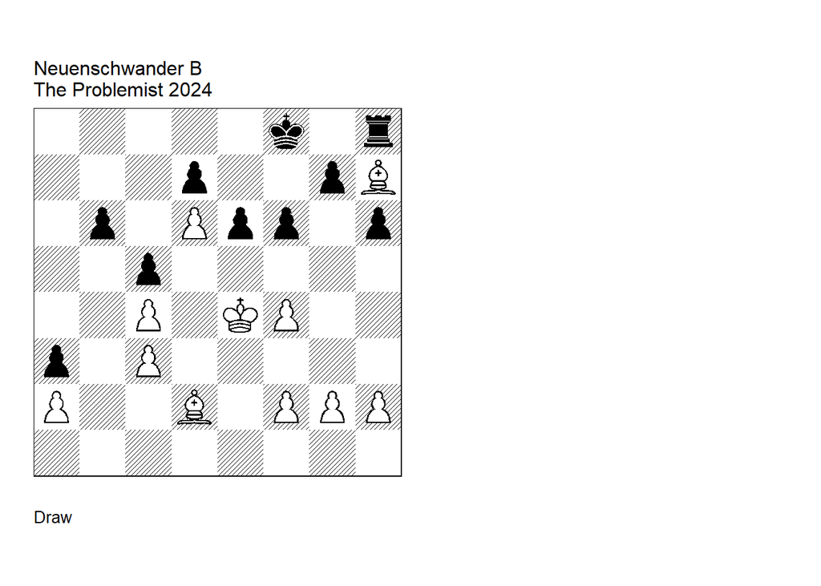

GBR: =0320.88e4f8 FEN: 5k1r/3p2pB/1p1Ppp1p/2p5/2P1KP2/p1P5/P2B1PPP/8 w - - 0 1

**1. Bg6 f5+ 2. Ke5!** (2. Kd3? h5 3. h4 Rh6 4. g4 Rxg6 5. g5 Ke8! (5… e5? 6. fxe5 Re6 7. f4) 6. Kc2 Kd8 7. Kb3 Kc8 8. Ka4 Kb7 9. Kb5 e5 10. fxe5 Re6 11. f4 Re8 12. Ka4 Ra8+ 13. Kb3 Kc6 14. Bc1 Ra5 15. Bxa3 b5 -/+) **2… h5 3. h4 Rh6 4. g4!! Rxg6 5. g5 Kf7 6. Bc1! Tempo!** (6. Be3? Rf6 7. Bxc5 bxc5 8. f3 Kg6 Zugzwang 9. gxf6 gxf6 ) (6. f3? Rf6 7. Be3 Kg6 8. Bf2 Rf8 9. Bxc5 Rc8 -/+) **6… Rf6 7. Be3!** (7. Bxa3? Kg6 8. Bc1 Rf8 -/+) **7… Kg6 8. Bxc5!** (8. f3? Rf8 9. Bxc5 Rc8 -/+) **8… bxc5 9. f3 Now Black is in Zugzwang 9… Kf7 10. g6+ 1/2-1/2**.

# Comments and revisions

## Tidskrift for Schack studies (continued)

Date: 2024, June 7

File: Hildebrand1945a.pgn

In the correction Black wins after **4… Bc8!** due to the f-pawn. The study can be corrected by moving the f-pawn to h7.

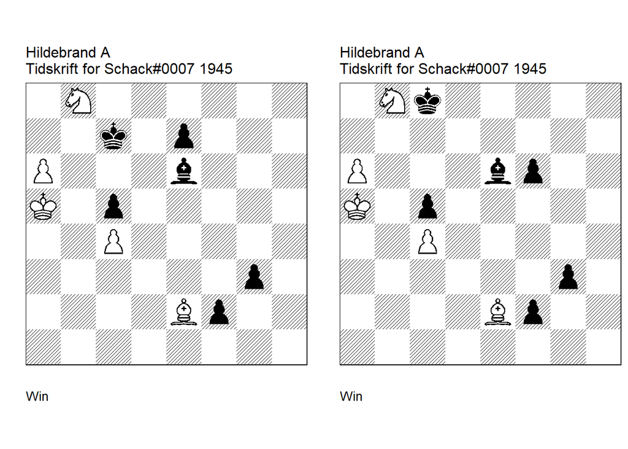

GBR: +0041.24a5c7 FEN: 1N6/2k1p3/P3b3/K1p5/2P5/6p1/4Bp2/8 w - - 0 1

**Tidskrift for Schack=2 Tidskrift for Schack/2. U3: Tidskrift for Schack=5 5/1945. 1. a7 Kb7 2. Bf1 Kxa7 3. Nc6+ Ka8 4. Bg2** (4. Nxe7? Kb8! 5. Nd5! Bg4 6. Ne3 Bf3 7. Kb6 Kc8 8. Kxc5 Kc7 9. Ng2 Kb7 10. Nh4 Bc6 11. Kd4 Kb6 12. Ke3 Kc5 13. Kf4 g2) **4… f1=Q 5. Bxf1 Bxc4 6. Bg2 e6! cook 7. Ne5+ Bd5 1-0**.

GBR: +0041.24a5c8 FEN: 1Nk5/8/P3bp2/K1p5/2P5/6p1/4Bp2/8 w - - 0 1

**Tidskrift for Schack=2 Tidskrift for Schack/2. correction: Hildebrand=A Tidskrift for Schack=6 6/1945. U3: Neuenschwander=B beatochess 07/06/2024. 1. a7 Kb7 2. Bf1 Kxa7 3. Nc6+ Ka8 4. Bg2 f1=Q** (4… Bc8! cook BN 5. Kb6 Bb7 6. Kxc5 f5! 7. Kd4 f4) **5. Bxf1 Bxc4 6. Bg2 1-0**.

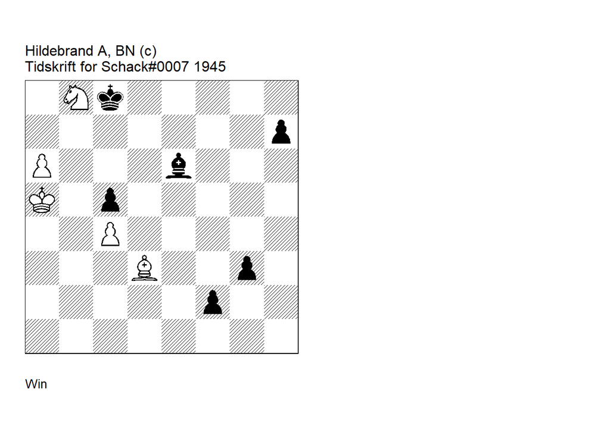

**correction: Neuenschwander=B beatochess 07/06/2024. 1. a7** (1. Kb6? g2 2. a7 f1=Q 3. a8=Q Qf6!) **1… Kb7 2. Bf1 Kxa7 3. Nc6+ Ka8 4. Bg2 f1=Q 5. Bxf1 Bxc4 6. Bg2 1-0**.

### Hildebrand =0034.21a5a3 (1945). Cook

The study is incorrect: in the line **2… Nb6**, Black wins with **4… Kb4!**.

Date: 2024, June 18

File: Hildebrand1945b.pgn

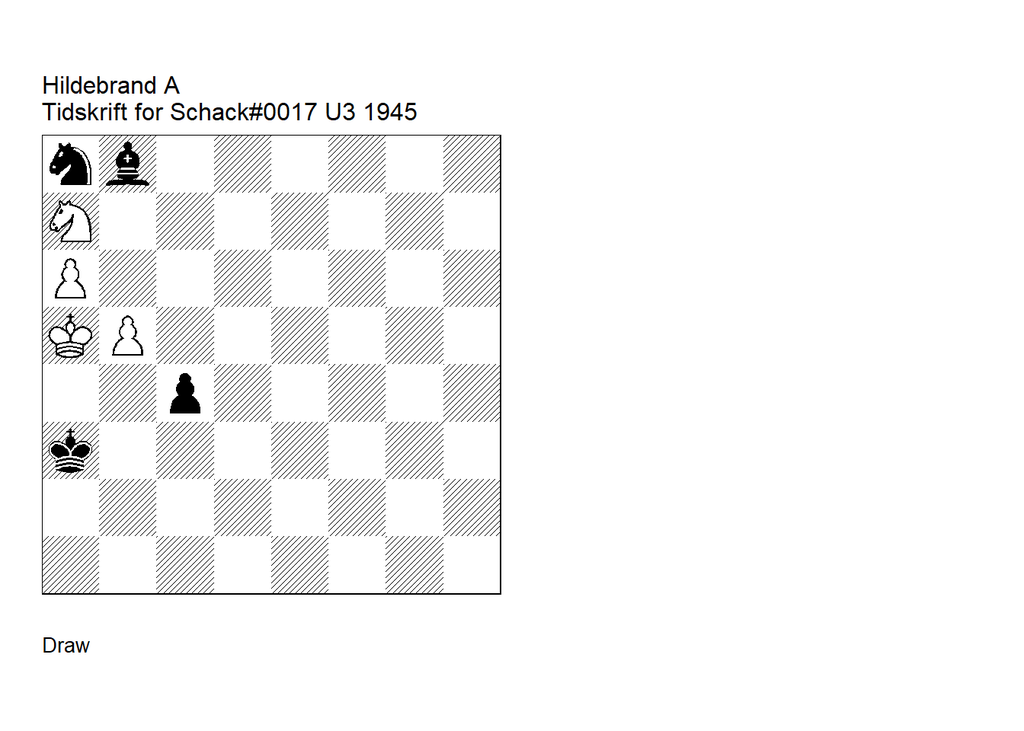

GBR: =0034.21a5a3 FEN: nb6/N7/P7/KP6/2p5/k7/8/8 w - - 0 1

**Tidskrift for Schack=3 Tidskrift for Schack/3 U3: Neuenschwander=B beatochess 18/06/2024. 1. b6!** (1. Nc6? c3 2. Nb4 Bc7+ 3. b6 Bxb6+ 4. Kb5 Nc7+! 5. Kc4 (5. Kxb6 Kxb4 6. Kxc7 c2 7. a7 c1=Q+) 5… Nxa6! 6. Nd3 c2 7. Kc3 Nb4) **1… Bxa7 2. b7 Nc7** (2… Nb6 3. b8=Q Bxb8 4. Kxb6 c3 (4… Bh2 5. a7 Bg1+ 6. Kb5 Bxa7 7. Kxc4) (4… Kb4! cook BN 5. Kb7 Kb5) 5. Kb7) **3. b8=Q Bxb8 4. a7 Bxa7 1/2-1/2**.

### Terho +0345.46h2a8 (1945). Comment

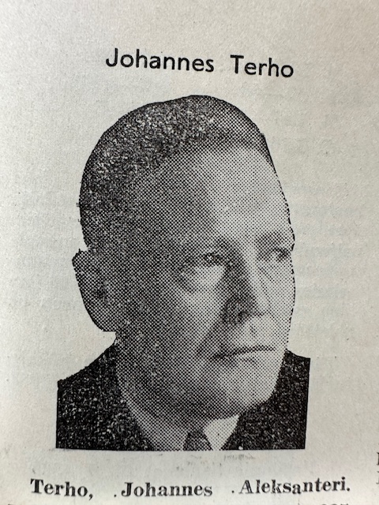

Source: A.Dunder and A. Hinds, *111 suomalaista Lopputehtävää*, Suoman Shakki, Jyväskylä, 1946.

**Johannes Terho** (1885-1961) was a Finnisch chess player and study composer. 46 studies can be found in **HHdbVI**, of which 35 are original studies by the author; 14 of the 35 studies are cooked (40%). the remaining 11 consist of 10 corrections and one version.

Date: 2024, June 18

File: Terho1945.pgn

Terho’s study is incorrect: **5.c5!** also wins.

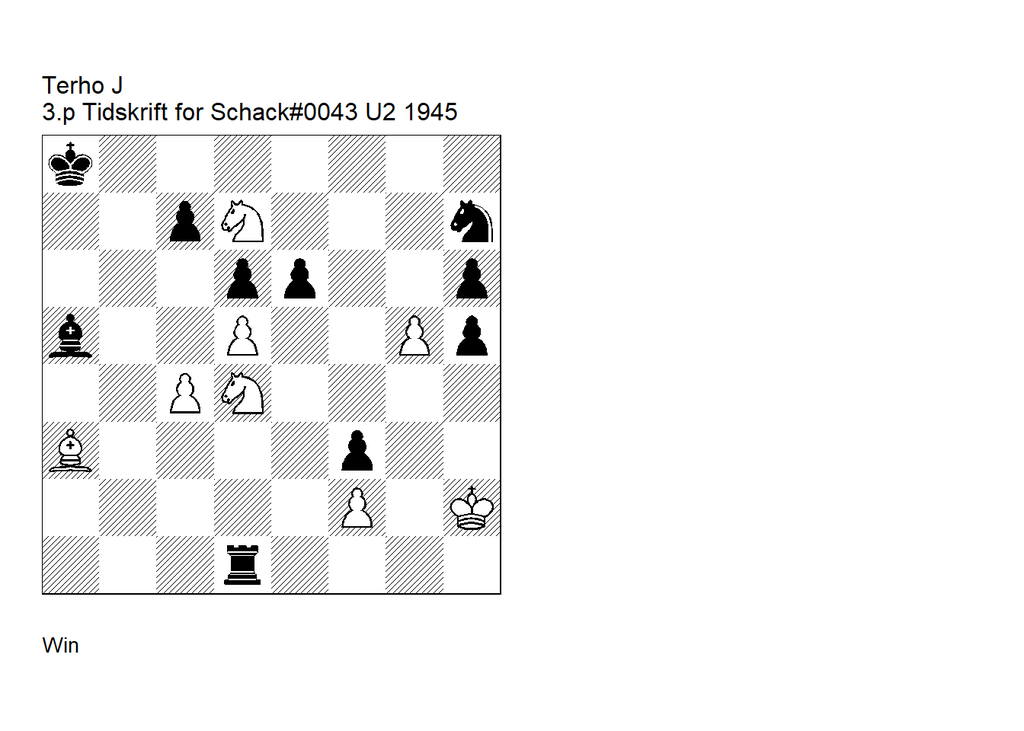

GBR: +0345.46h2a8 FEN: k7/2pN3n/3pp2p/b2P2Pp/2PN4/B4p2/5P1K/3r4 w - - 0 1

**Tidskrift for Schack=7 Tidskrift for Schack/7 U2: Neuenschwander=B beatochess 18/06/2024. 1. g6** (1. dxe6? Rxd4 2. e7 Re4) **1… Rxd4 2. gxh7 Rh4+ 3. Kg3! Rg4+ 4. Kxf3 Bc3 5. Nf6!** (5. dxe6? Rg6 6. Nf6 Rxf6+) (5. c5! cook BN 5… dxc5 (5… exd5 6. cxd6 cxd6 7. Bxd6) (5… Rg6 6. cxd6 cxd6 7. Bxd6 exd5 8. Ne5) 6. dxe6 Rg6 7. e7 Re6 8. Bxc5) **5… Bxf6 6. dxe6 Rg1 7. Bb4** (7. Ke2? Rg5 8. Bb2 Bxb2 9. e7) **7… Rg5 8. Bc3! Bxc3 9. e7 Re5 10. h8=Q+ 1-0**.

### Hannemann =0011.02b8b3 (1945). Version

Date: 2024, June 18

File: Hannemann1945.pgn

In Hannemann’s study, **1. Ne4** is not a cook. The other cooks remain though. My version shows the sacrifice of the white bishop twice (on a4 and a6 in the two mainlines). Either black takes the bishop or the well-known BN-q theoretical draw is reached.

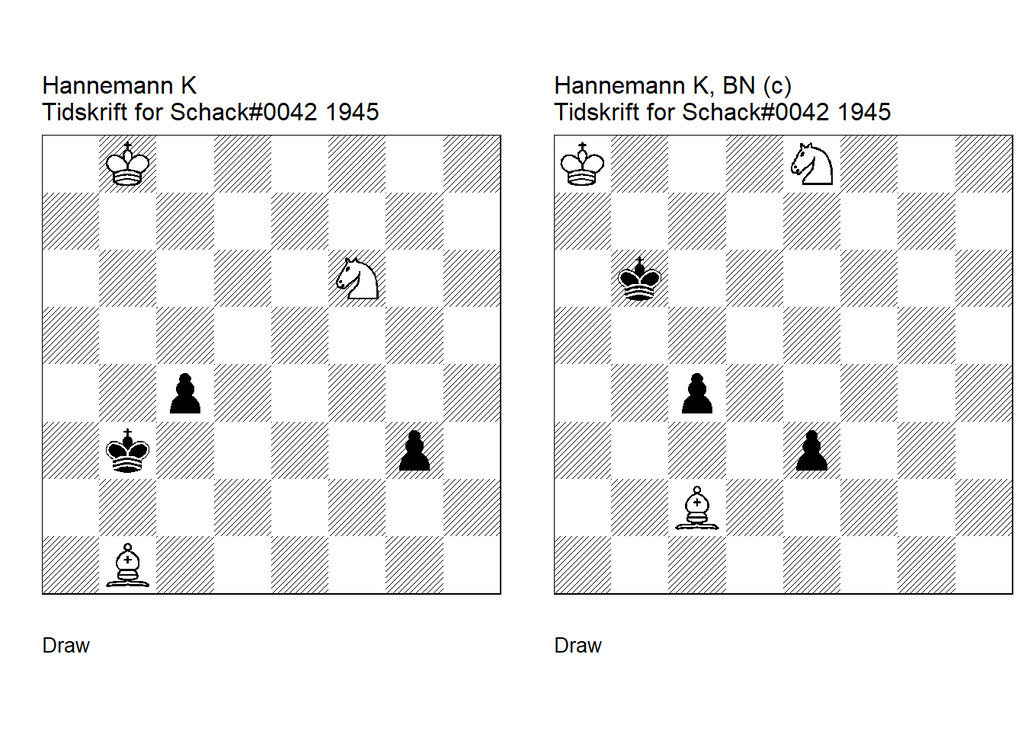

GBR: =0011.02b8b3 FEN: 1K6/8/5N2/8/2p5/1k4p1/8/1B6 w - - 0 1

**Tidskrift for Schack=7 Tidskrift for Schack/7. U1 U2: Tidskrift for Schack=10 10/1945 Comment Neuenschwander=B 18/06/2024. 1. Be4** (1. Ne4! cook 1… g2 2. Nd2+ Kb2 3. Nxc4+ Kc1 4. Be4 commnt BN: black is winning! ) **1… c3 2. Ka7** (2. Ka8! cook 2… Ka3 3. Nd5 c2 4. Bxc2 g2 5. Ba4! g1=Q (5… Kxa4 6. Nc3+ Kb3 7. Ne2) 6. Bc6) (2. Nd5! cook 2… g2 3. Bxg2 c2 4. Bf1 c1=Q 5. Ba6) **2… Ka3** (2… Kb2 3. Nd5 c2 4. Nb4) ( 2… Ka2 3. Nd5 c2 4. Nb4+) **3. Ka8 c2 4. Bxc2 g2 5. Be4 g1=Q 6. Bb7 1/2-1/2**.

GBR: =0011.02a8b6 FEN: K3N3/8/1k6/8/2p5/4p3/2B5/8 w - - 0 1

**version: Neuenschwander=B beatochess 18/06/2024. 1. Bd1 c3 2. Nf6 Ka5 3. Nd5 c2** (3… e2 main 4. Bxe2 c2 5. Ba6! c1=Q 6. Kb7) **4. Bxc2 e2 5. Ba4! e1=Q 6. Bc6 1/2-1/2**.

### Hildebrand +0024.02f2a2 (1945). Comment

Date: 2024, June 19

File: Hildebrand1945c.pgn

Another example of a failed study due to the fact that the BB-n ending is lost.

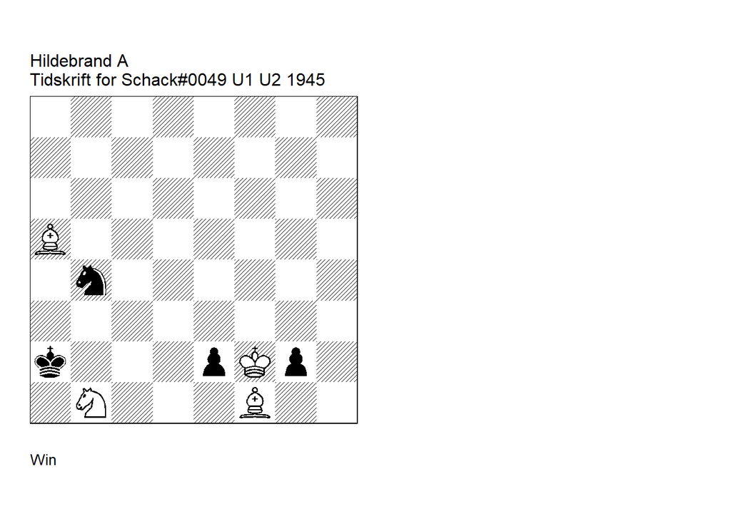

GBR: +0024.02f2a2 FEN: 8/8/8/B7/1n6/8/k3pKp1/1N3B2 w - - 0 1

**Tidskrift for Schack=8 Tidskrift for Schack/8. U1 U2 Neuenschwander=B beatochess 19/06/2024. 1. Bxg2!** (1. Bxe2? Nc6! 2. Nc3+ Kb3) (1. Bxe2! cook BN 1… Nc6 2. Bc3 Kxb1 3. Kxg2) **1… Nd3+ 2. Kxe2 Nc1+** (2… Nf4+ 3. Kf3 Nxg2 4. Nc3+ Kb3 5. Kxg2) **3. Kd2!** (3. Kd1? Kxb1 4. Be4+ Kb2) (3. Ke3! cook BN any king move wins ) **3… Nb3+** (3… Kxb1 4. Be4+ Kb2 5. Bc3+ Kb3 6. Bd5+) **4. Kc2 Nxa5 5. Bd5+ Ka1 6. Nd2! 1-0**.

### Book =0000.44f2e4 (1946). Duals

Date: 2024, July 2

File: Book1946.pgn

**2. c3!** is a remarkable move. **3. Ke3** as well as **3. Ke1** are (minor?) duals.

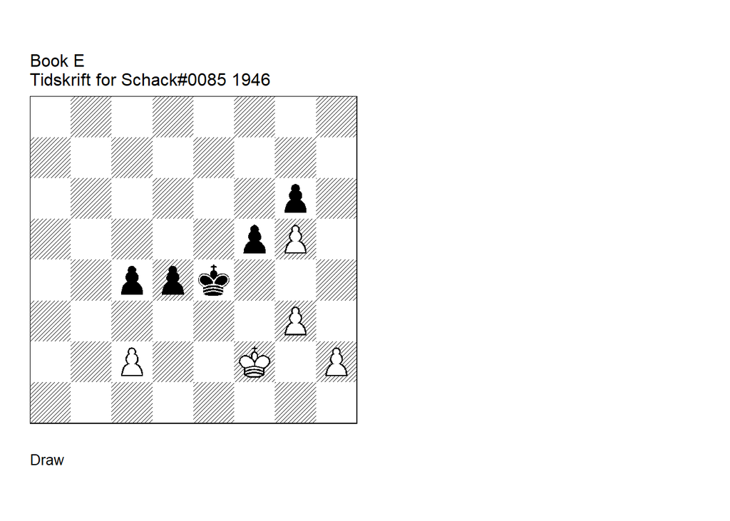

GBR: =0000.44f2e4 FEN: 8/8/6p1/5pP1/2ppk3/6P1/2P2K1P/8 w - - 0 1

**Tidskrift for Schack=2 Tidskrift for Schack/2** (U2) **: Neuenschwander=B beatochess 02/07/2024. 1. h4! Ke5** (1… d3 2. cxd3+ Kxd3 3. h5) **2. c3!** (2. Kf3? f4! 3. gxf4+ (3. g4 c3! 4. h5 d3) (3. c3 fxg3! 4. cxd4+ Kf5) (3. h5 gxh5 4. g6 Kf6 5. Kxf4 Kxg6 6. Ke4 Kg5 7. Kxd4 Kg4 8. Kxc4 Kxg3 9. Kb5 h4) 3… Kf5 4. c3! d3! 5. Ke3 Kg4) **2… dxc3!** (2… d3 3. Ke3 f4+ 4. gxf4+ Kf5 5. Kf3) **3. Ke2** (3. Ke3! dual BN 3… f4+ 4. gxf4+ Kf5 5. Ke2 Kxf4) ( 3. Ke1! dual BN ) **3… f4 4. gxf4+ Kxf4 5. h5! Kxg5 6. hxg6 Kxg6 7. Kd1 1/2-1/2**.

### Hall =0602.00f3g6 (1946). Cook

Date: 2024, July 2

File: Hall1946.pgn

**1… Rxc6** leads to a lost N-r ending.

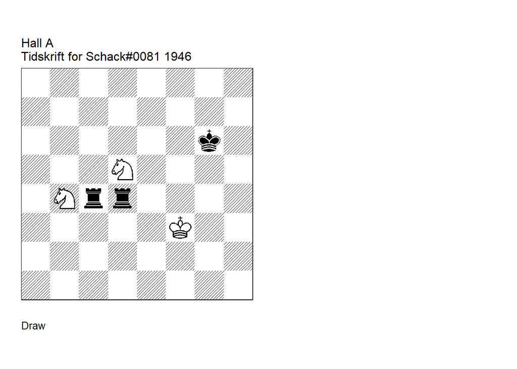

GBR: =0602.00f3g6 FEN: 8/8/6k1/3N4/1Nrr4/5K2/8/8 w - - 0 1

**Tidskrift for Schack=1 Tidskrift for Schack/1 U3: Neuenschwander=B beatochess 02/07/2024. 1. Nc6 Re4** (1… Rxc6! cook BN 2. Ne7+ Kf6 3. Nxc6 Rc4 4. Na5 Rc5 5. Nb7 Rd5 6. Ke4 Ke6) **2. Na5 Rcd4** (2… Ra4 3. Nc3 Rf4+ 4. Ke3 Rab4 5. Nc6 Rbc4 6. Ne5+) **3. Nb3 Rc4** (3… Ra4 4. Nc5) **4. Nd2 1/2-1/2**.

### Hildebrand +0260.01c4b2 (1946). Cook

Date: 2024, July 2

File: Hildebrand1946a.pgn

When the R-b position is reached, **5. Kd4** and **6. Kc3** also win.

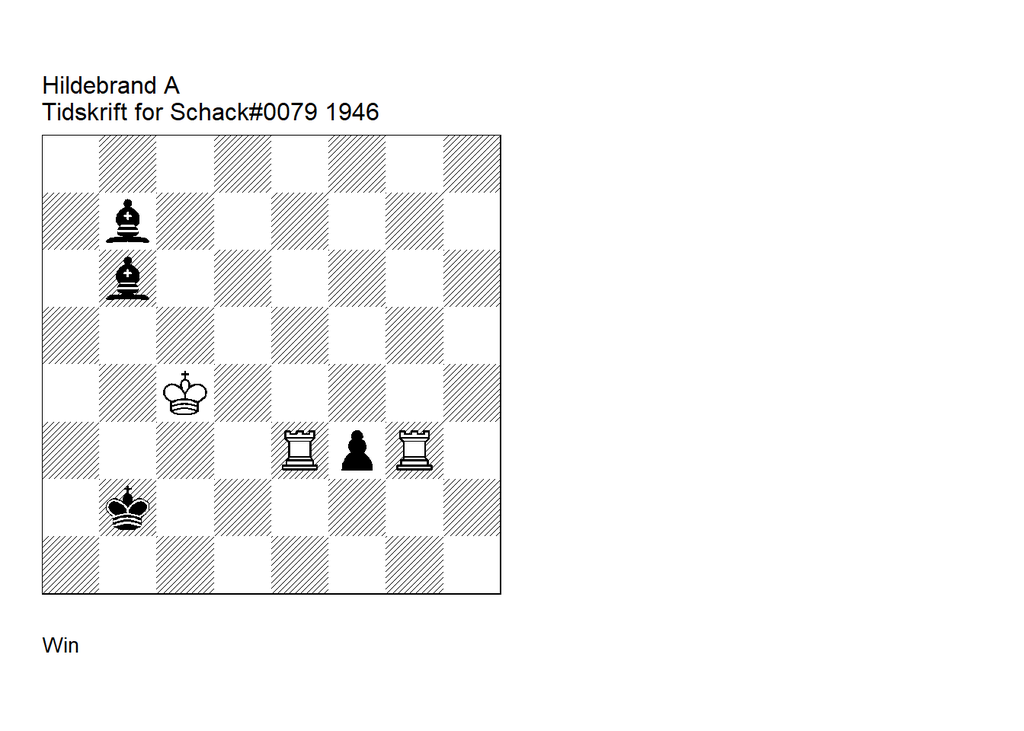

GBR: +0260.01c4b2 FEN: 8/1b6/1b6/8/2K5/4RpR1/1k6/8 w - - 0 1

**Tidskrift for Schack=1 Tidskrift for Schack/1 U2: Neuenschwander=B beatochess 02/07/2024. 1. Rb3+ Ka2!** (1… Kc2 2. Rxb6 f2 3. Rc3+ Kd1 4. Rb1+ Ke2 5. Rb2+!) **2. Rxb6 f2 3. Rf6 f1=Q+! 4. Rxf1 Ba6+ 5. Kb4!** (5. Kd4! cook BN 5… Bxf1 6. Kc3) (5. Kc3! cook BN 5… Bxf1 6. Rg5 Bh3 7. Kc2) **5… Bxf1 6. Rf3!** (6. Kc3! cook BN 6… Bb5 7. Rg2+ Ka3 8. Rg7) **6… Bg2** (6… Be2 7. Rf2) **7. Rf2+ Kb1 8. Rxg2 1-0**.

Date: 2024, July 3

File: Terho1946.pgn

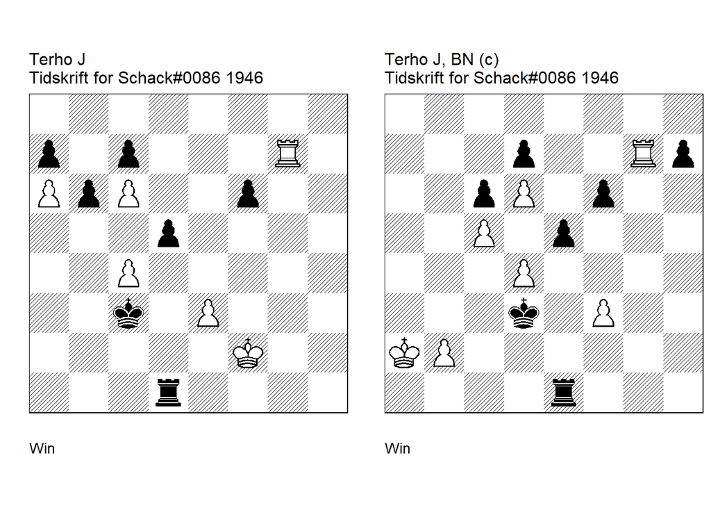

GBR: +0400.45f2c3 FEN: 8/p1p3R1/PpP2p2/3p4/2P5/2k1P3/5K2/3r4 w - - 0 1

**Tidskrift for Schack=2 Tidskrift for Schack/2 U3: Neuenschwander=B beatochess 02/07/2024. 1. c5!** (1. Rxc7? Kxc4 2. Rxa7 Kb5 3. c7 Rc1) **1… Kb4 2. cxb6 cxb6 3. Rg4+ Kb5** (3… Kb3! cook BN 4. Rc4 dxc4 5. c7 c3 6. c8=Q c2) **4. Rc4! dxc4 5. c7 1-0**.

GBR: +0400.55a2d3 FEN: 8/3p2Rp/2pP1p2/2P1p3/3P4/3k1P2/KP6/4r3 w - - 0 1

**correction: Neuenschwander=B beatochess 03/07/2024. 1. d5 Kc4 2. dxc6 dxc6 3. Rg4+ Kxc5 4. Rd4 exd4 5. d7 1-0**.

## Shakhmatny Listok, Shakhmaty v SSSR (continued)

### Aizenshtat +3100.52h7f8 (1931). Correction

Date: 2024, June 4

File: Aizenshtat1931a.pgn

A slower win beginning with **2. Kh6** is possible in Aizenshtat’s study. The correction is a bit richer in content.

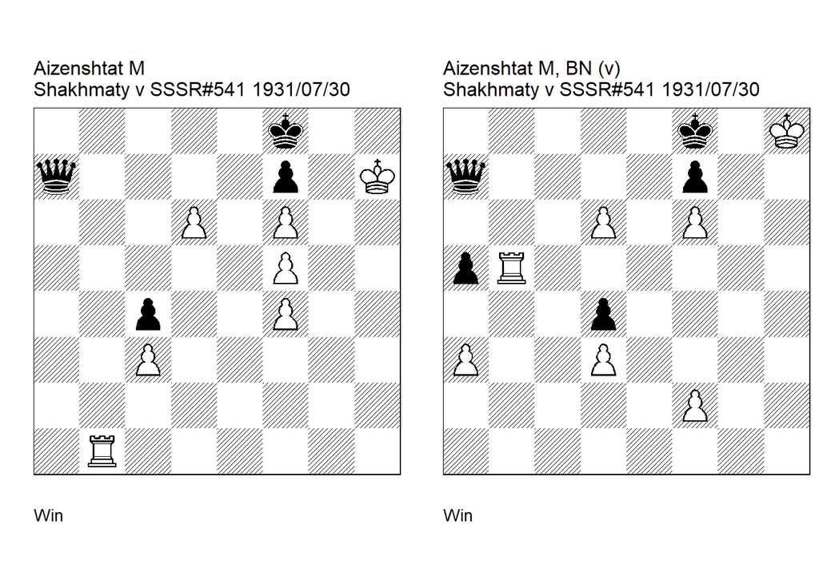

GBR: +3100.52h7f8 FEN: 5k2/q4p1K/3P1P2/5P2/2p2P2/2P5/8/1R6 w - - 0 1

**Shakhmaty v SSSR=14 U2: Neuenschwander=B beatochess 04/06/2024 . 1. d7 Qa8!** (1… Qb6 2. Rd1 Qd8 (2… Qd6 3. d8=Q+) 3. Rd2) (1… Qxd7 2. Rb8+ Qe8 3. Rxe8+ Kxe8 4. Kg7) **2. Rb7!** (2. Rd1? Qh1+! 3. Rxh1) (2. Kh6! cook BN 2… Qd8 3. Kh5 Kg8 4. Rd1 Kh7 5. Kg4 Qa8 6. Rd2) **2… Qd8 3. Rb2!** (3. Ra7? Qa5! 4. Kh6 Qd5! 5. Ra1 Kg8 6. Rg1+ (6. Rb1 Qd6!) 6… Kh8 7. Ra1 Kg8) **3… Qa8 4. Rg2! 1-0**.

GBR: +3100.53h8f8 FEN: 5k1K/q4p2/3P1P2/pR6/3p4/P2P4/5P2/8 w - - 0 1

**version: Neuenschwander=B beatochess 04/06/2024. 1. d7 Qc7 2. f4 Qd8 3. Kh7 Qa8 4. Rb1!** (4. Rb7? a4! 5. Kh8 Qd8 6. Kh7 Qa8 7. Rb1 Qh1+ 8. Rxh1) **4… a4 5. Rb7! Qd8 6. Rb2!** (6. Ra7? Qa5!) **6… Qa8 7. Rg2! 1-0**.

### Aizenshtat +0040.13c6a5 (1931). Correction

Date: 2024, June 4

File: Aizenshtat1931b.pgn

The dual in the original study is rather minor since the winning idea remains the same. The correction rectifies this minor flaw.

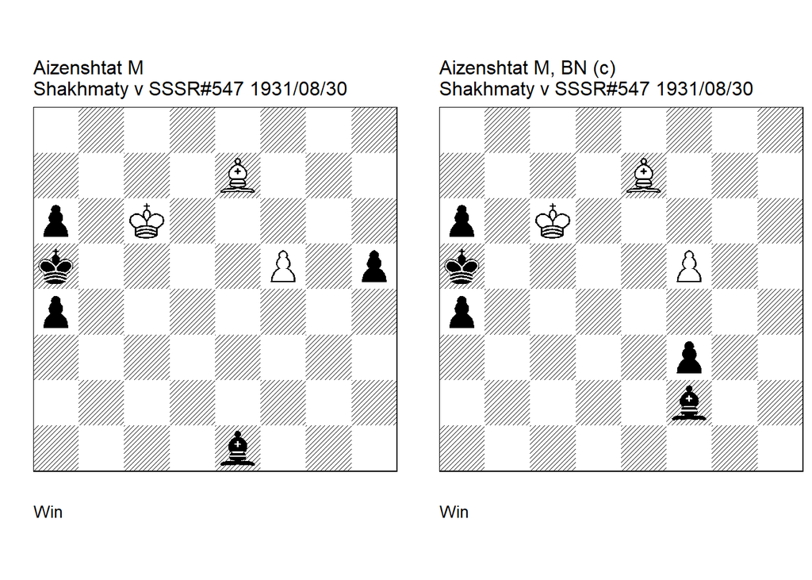

GBR: +0040.13c6a5 FEN: 8/4B3/p1K5/k4P1p/p7/8/8/4b3 w - - 0 1

**Shakhmaty v SSSR=16 U2: Neuenschwander=B beatochess 04/06/2024. 1. f6 Bc3** ( 1… Bd2 main 2. f7 Bh6 3. Bg5! Bf8 4. Bd2+) (1… Bh4 main 2. Bd8+! Kb4 3. f7) (1… a3 2. f7 a2 3. f8=Q a1=Q 4. Qf5+ Ka4 5. Qc2+ Ka5 6. Qc5+ Ka4 7. Qc4+ Ka5 8. Bd8 ) **2. f7 Bg7 3. Bf6!** (3. Ba3! dual BN 3… h4 4. Bb2 Bf8 5. Bc3+) **3… Bf8 4. Bc3+ Bb4 eg 5. f8=Q Bxc3 6. Qc5 1-0**.

GBR: +0040.13c6a5 FEN: 8/4B3/p1K5/k4P2/p7/5p2/5b2/8 w - - 0 1

**correction: Neuenschwander=B beatochess 04/06/2024. 1. f6 Bd4** (1… Be3 main 2. f7 Bh6 3. Bg5! Bf8 4. Bd2+) (1… Bh4 2. Bd8+ Kb4 3. f7) **2. f7 Bg7 3. Bf6! Bf8 4. Bc3+ 1-0**.

### Videnkin =0044.21b4e5 (1930). Correction

Date: 2024, June 5

File: Videnkin1930.pgn

With the bishop on f6 instead of g7 in the main line, the cook can be avoided. This is used in the correction.

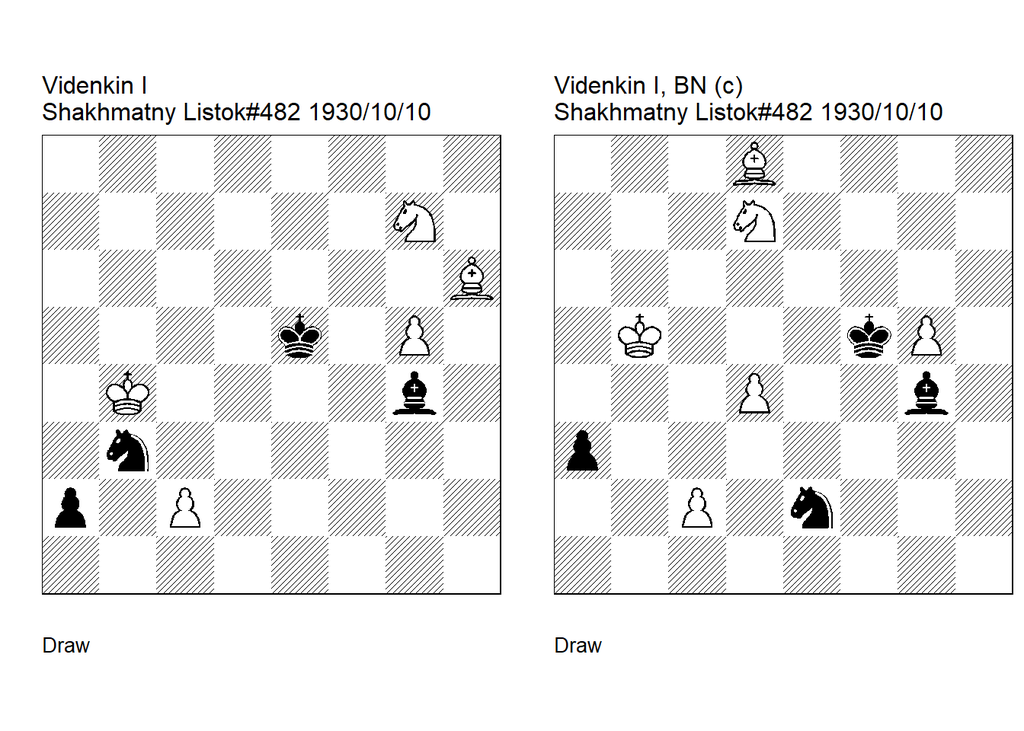

GBR: =0044.21b4e5 FEN: 8/6N1/7B/4k1P1/1K4b1/1n6/p1P5/8 w - - 0 1

**Shakhmatny Listok=19 U3: Neuenschwander=B beatochess 05/06/2024 . 1. Nf5 Kxf5 2. Bg7 a1=Q** (2… Kg6 3. Kxb3 Be6+ 4. Kb2) (2… Nc1! cook BN 3. Ka3 Kg6! (3… Kxg5? 4. Kb2) 4. Bh8 Be6) **3. Bxa1 Nxa1 4. Kc3 Bd1! 5. g6! Kxg6 6. Kb2 Nxc2 7. Kc1! Ne3 8. Kd2 1/2-1/2**.

GBR: =0044.31b5f5 FEN: 3B4/3N4/8/1K3kP1/3P2b1/p7/2P1n3/8 w - - 0 1

**correction: Neuenschwander=B beatochess 05/06/2024. 1. Nc5** (1. Bf6? Nc3+ 2. Kb4 a2) **1… Nxd4+ 2. Kb4 a2 3. Nb3 Nxb3 4. Bf6 a1=Q** (4… Nc1 5. Ka3 Kg6 6. Kb2 Be6 7. Kxc1) **5. Bxa1 Nxa1 6. Kc3 Bd1 7. g6! Kxg6 8. Kb2 Nxc2 9. Kc1 Ne3 10. Kd2 1/2-1/2**.